# All Homework Answers

# HW-2019-11-22

## Question

Exercise 8.3(pages 243, Statistical Computating with R) and slides page 31.

## Answer

### 1. Exercises 8.3

The Count 5 test for equal variances in Section 6.4 is based on the maximum number of extreme points. Example 6.15 shows that the Count 5 criterion is not applicable for unequal sample sizes. Implement a permutation test for equal variance based on the maximum number of extreme points that applies when sample sizes are not necessarily equal.

First implement a permutation test for equal variance based on the maximum number of extreme points.

```r
count5test<-function(x,y){
   x<-x-mean(x)
   y<-y-mean(y)
   outx<-sum(x>max(y))+sum(x<min(y))
   outy<-sum(y>max(x))+sum(y<min(y))
   return(as.integer(max(c(outx,outy))>5))
}
permutation_test<-function(R,n){
   x<-rnorm(n1,mu1,sigma1)
   y<-rnorm(n2,mu2,sigma2)
   z<-c(x,y)
   reps<-numeric(R)
   for(i in 1:R){
      k<-sample(1:n,size=n1,replace = FALSE)
      x1<-z[k]
      reps[i]<-count5test(x1,x)
   }
   mean(reps)
}
```

Check the test when sample sizes are equal.

```r
#when sample sizes are equal
n1<-n2<-20
mu1<-mu2<-0
sigma1<-sigma2<-1
R<-999
m<-1000
set.seed(123)
alphahat1<-mean(replicate(m,permutation_test(R,n1+n2)))
round(alphahat1,4)
```

```
## [1] 0.0055
```

When sample sizes are equal,the empirical Type I error rate was 0.0055.It is controlled well.

Then estimate the empirical Type I error rate when sample sizes are unequal.

```r
#when sample sizes are unequal
n1<-20
n2<-30
set.seed(1234)
alphahat2<-mean(replicate(m,permutation_test(R,n1+n2)))
n1<-20
n2<-35
set.seed(1233)
alphahat3<-mean(replicate(m,permutation_test(R,n1+n2)))
n1<-20
n2<-40
set.seed(1232)
alphahat4<-mean(replicate(m,permutation_test(R,n1+n2)))
n1<-20
n2<-50
set.seed(1231)
alphahat5<-mean(replicate(m,permutation_test(R,n1+n2)))
a<-matrix(c(alphahat2,alphahat3,alphahat4,alphahat5),ncol=4)
colnames(a)<-c("n1=20,n2=30","n1=20,n2=35","n1=20,n2=40","n1=20,n2=50")
rownames(a)<-"type I error"
round(a,4)
```

```
##              n1=20,n2=30 n1=20,n2=35 n1=20,n2=40 n1=20,n2=50
## type I error      0.0093      0.0094       0.012      0.0149
```

We can see that the empirical Type I error rate was controlled less than 0.05.

### 2.slides page 31

Power comparison(distance correlation test versus ball covariance test).

Model 1:$Y=X/4+e$

Model 2:$Y=X/4×e$

$X\sim N(0_{2},I_{2}),e\sim N(0_{2},I_{2})$,X and e are independent.

Basic idea:

First write the function of distance correlation test.

Then for each model,calculate powers of two methods.

Finally show the power comparison by plots.

```r
library(MASS)
library(boot)
library(Ball)
#function of distance correlation test
dCov <- function(x, y) {
   x <- as.matrix(x)
   y <- as.matrix(y)
   n <- nrow(x)
   m <- nrow(y)
   if (n != m || n < 2) stop("Sample sizes must agree")
   if (! (all(is.finite(c(x, y))))) stop("Data contains missing or infinite values")
   Akl <- function(x) {
     d <- as.matrix(dist(x))
     m <- rowMeans(d)
     M <- mean(d)
     a <- sweep(d, 1, m)
     b <- sweep(a, 2, m)
     return(b + M)
   }
   A <- Akl(x)
   B <- Akl(y)
   dCov <- sqrt(mean(A * B))
   dCov
}
ndCov2 <- function(z, ix, dims) {
  p <- dims[1]
  q <- dims[2]
  d <- p + q
  x <- z[ , 1:p] #leave x as is
  y <- z[ix, -(1:p)] #permute rows of y
  return(nrow(z) * dCov(x, y)^2)
}

#p-values of two models
p_model1<-function(n){
   p.cor<-numeric(length(n))
   p.ball<-numeric(length(n))
   for(i in 1:length(n)){
     N<-n[i]
     x1<-mvrnorm(N,rep(0,2),matrix(c(1,0,0,1),nrow=2))
     e1<-mvrnorm(N,rep(0,2),matrix(c(1,0,0,1),nrow=2))
     y1<-x1/4+e1
     z1<-as.matrix(cbind(x1,y1))
     boot.obj1<-boot(data=z1,statistic = ndCov2,R=999,sim = "permutation",dims=c(2,2))
     tb1<-c(boot.obj1$t0,boot.obj1$t)
     p.cor[i]<-mean(tb1>=tb1[1])
     p.ball[i]<-bcov.test(x1,y1,R=999,seed=sample(1:100000,size = 1))$p.value
   }
   return(c(p.cor,p.ball))
}

p_model2<-function(n){
 p.cor<-numeric(length(n))
 p.ball<-numeric(length(n))
 for(i in 1:length(n)){
   N<-n[i]
   x2<-mvrnorm(N,rep(0,2),matrix(c(1,0,0,1),nrow=2))
   e2<-mvrnorm(N,rep(0,2),matrix(c(1,0,0,1),nrow=2))
   y2<-cbind(x2[,1]*e2[,1]/4,x2[,2]*e2[,2]/4)
   z2<-as.matrix(cbind(x2,y2))
   boot.obj2<-boot(data=z2,statistic = ndCov2,R=999,sim = "permutation",dims=c(2,2))
   tb2<-c(boot.obj2$t0,boot.obj2$t)
   p.cor[i]<-mean(tb2>=tb2[1])
   p.ball[i]<-bcov.test(x2,y2,R=999,seed=sample(1:100000,size = 1))$p.value
 }
  return(c(p.cor,p.ball))
}
```

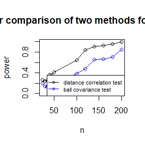

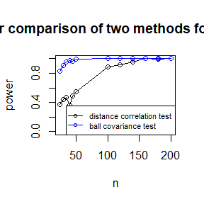

```r
n<-c(seq(25,50,5),seq(100,200,20))
m<-100
set.seed(12)

#powers of two models
pow1<-apply(replicate(m,p_model1(n))<=0.05,1,mean)
pow2<-apply(replicate(m,p_model2(n))<=0.05,1,mean)

#power comparison by plots
plot(n,pow1[1:length(n)],type = "o",ylim=c(0,1),ylab="power",main="power comparison of two methods for model 1")
lines(n,pow1[(length(n)+1):(2*length(n))],type="o",col="blue")
legend("bottomright",c("distance correlation test","ball covariance test"),col=c("black","blue"),cex=0.7,lty=1,pch=1)
plot(n,pow2[1:length(n)],type = "o",ylim=c(0,1),ylab="power",main="power comparison of two methods for model 2")
lines(n,pow2[(length(n)+1):(2*length(n))],type="o",col="blue")
legend("bottomright",c("distance correlation test","ball covariance test"),col=c("black","blue"),cex=0.7,lty=1,pch=1)
```

From the plots,we can find that for model 1, the power of distance correlation test is bigger than ball covariance test. And for model 2, the power of ball covariance test is bigger than distance correlation test.

# HW-2019-11-29

## Question

Exercise 9.4(pages 277, Statistical Computating with R)

## Answer

### 1. Exercises 9.4

Implement a random walk Metropolis sampler for generating the standard Laplace distribution (see Exercise 3.2). For the increment, simulate from a normal distribution. Compare the chains generated when different variances are used for the proposal distribution. Also, compute the acceptance rates of each chain.

The standard Laplace distribution has density $f(x)=\frac{1}{2} e^{-|x|}, x \in \mathbb{R}$,so $r\left(x_{t}, y\right)=\frac{f(Y)}{f\left(X_{t}\right)}=\frac{e^{-|y|}}{e^{-|x_{t}|}}=\frac{e^{|x_{t}|}}{e^{|y|}}$.

Then write a function to generate the chain,given the parameters $\sigma$,initial value $X_{0}$ and the length of the chain N.

```r
rw.Metropolis<-function(sigma,x0,N){
   x<-numeric(N)
   x[1]<-x0
   u<-runif(N)
   k<-0
   for(i in 2:N){
      y<-rnorm(1,x[i-1],sigma)
      if(u[i]<=(exp(abs(x[i-1]))/exp(abs(y)))) x[i]<-y
      else{
         x[i]<-x[i-1]
         k<-k+1
      }
   }
   return(list(x=x,k=k))
}
```

For diferent variances $\sigma^{2}$ of the proposal distribution ,we generate different chains:

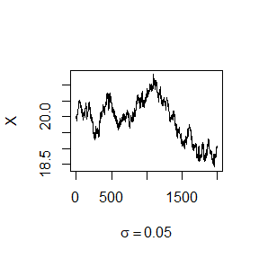

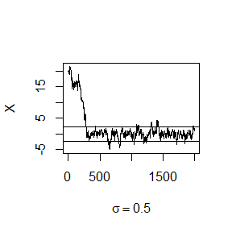

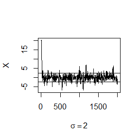

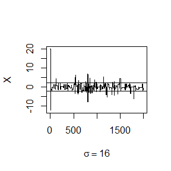

```r
N<-2000
sigma<-c(0.05,0.5,2,16)
x0<-20
set.seed(12)
rw1<-rw.Metropolis(sigma[1],x0,N)
rw2<-rw.Metropolis(sigma[2],x0,N)
rw3<-rw.Metropolis(sigma[3],x0,N)
rw4<-rw.Metropolis(sigma[4],x0,N)

#par(mfrow=c(2,2)) #display 6 graphs together
#the 0.05 and 0.95 quantile of laplace distribution is log(0.1) and -log(0.1)
refline <- c(log(0.1),-log(0.1))
rw <- cbind(rw1$x, rw2$x, rw3$x, rw4$x)
for (j in 1:4) {
 plot(rw[,j], type="l",xlab=bquote(sigma == .(round(sigma[j],3))),ylab="X",ylim=range(rw[,j]))
 abline(h=refline)
}
```

The plots show that the random walk Metropolis sampler is very sensitive to the variance of the proposal distribution.From the plot,I prefer to choose $\sigma=2$ because the chain is mixing well and converging to the target distribution after a short period.

Then we compute the acceptance rates of each chain.

```r
a<-matrix(1-c(rw1$k,rw2$k,rw3$k,rw4$k)/N,ncol=4)
colnames(a)<-c("σ = 0.05","σ = 0.5","σ = 2","σ = 16")
rownames(a)<-"acceptance rate"
print(a)
```

```
##                 σ = 0.05 σ = 0.5 σ = 2 σ = 16
## acceptance rate    0.984   0.809 0.523  0.115
```

We want a chain which has a rejection rate in the range [0.15,0.5],that is,an acceptance rate in the range [0.5,0.85].So we would like to choose $\sigma=2$.

When $\sigma=2$,we compare the quantiles of the target distribution with the quantiles of the generated chain in a Q-Q plot.And we compare the histogram of the generated sample with the Laplace distribution density.

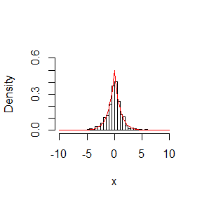

```r
#par(mfrow=c(1,2))
#histogram
x<-rw3$x
x<-x[x>-10&x<10]
hist(x,breaks=seq(-10,10,0.5),freq = FALSE,ylim=c(0,0.6),main="")
laplace<-function(x) 1/2*exp(-abs(x))
curve(laplace,from=-10,to=10,add=TRUE,col="red")
```

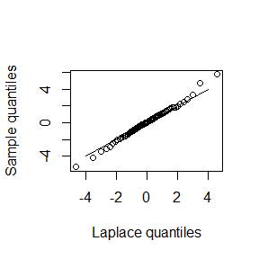

```r
#Q-Q plot
a<-ppoints(100)
y<-rw3$x[500:2000]
Q<-quantile(y,a)
QL<-c(log(2*a[a<=0.5]),-log(2*(1-a[a>0.5]))) #quantiles of Laplace
qqplot(QL,Q,xlab="Laplace quantiles",ylab="Sample quantiles")
lines(c(-4,4),c(-4,4),type="l")
```

From the plot, we can see that the generated samples fit well.

# HW-2019-12-06

## Question

Exercise 11.1 and 11.5(Statistical Computating with R pages 353-354),A-B-0 blood type problem.

## Answer

### 1. Exercises 11.1

The natural logarithm and exponential functions are inverses of each other, so that mathematically log(exp x) = exp(log x) = x. Show by example that this property does not hold exactly in computer arithmetic. Does the identity hold with near equality? (See all.equal.)

First use “isTRUE” to compare them.

```r
x<-5
c(isTRUE(log(exp(x))==exp(log(x))),isTRUE(exp(log(x))==x))
```

```
## [1] FALSE FALSE
```

```r
x<-10
c(isTRUE(log(exp(x))==exp(log(x))),isTRUE(exp(log(x))==x))
```

```
## [1] FALSE FALSE
```

For different x,the equations log(exp(x))=exp(log(x)) and exp(log(x))=x don’t hold exactly in computer arithmetic.

Then use “all.equal” to compare.

```r
x<-5
c(isTRUE(all.equal(log(exp(x)),exp(log(x)))),isTRUE(all.equal(exp(log(x)),x)))
```

```
## [1] TRUE TRUE
```

```r
x<-10
c(isTRUE(all.equal(log(exp(x)),exp(log(x)))),isTRUE(all.equal(exp(log(x)),x)))
```

```
## [1] TRUE TRUE
```

When using “all.equal” function,the identity holds.

### 2. Exercise 11.5

Write a function to solve the equation
$$\frac{2 \Gamma\left(\frac{k}{2}\right)}{\sqrt{\pi(k-1)} \Gamma\left(\frac{k-1}{2}\right)} \int_{0}^{c_{k-1}}\left(1+\frac{u^{2}}{k-1}\right)^{-k / 2} d u =\frac{2 \Gamma\left(\frac{k+1}{2}\right)}{\sqrt{\pi k} \Gamma\left(\frac{k}{2}\right)} \int_{0}^{c_{k}}\left(1+\frac{u^{2}}{k}\right)^{-(k+1) / 2} d u$$
for a, where $c_{k}=\sqrt{\frac{a^{2} k}{k+1-a^{2}}}$.Compare the solutions with the points A(k) in Exercise 11.4.

Use bisection algorithm to solve the equation in exercise 11.5.

```r
#exercise 11.5
set.seed(123)
ck<-function(k,a) sqrt((a^2)*k/(k+1-a^2))
f1<-function(k) exp(lgamma(k/2)-lgamma((k-1)/2))/sqrt(k-1)
f<-function(u)  (1+u^2/(k-1))^(-k/2)
f2<-function(c,k) integrate(f,lower=0,upper=c)$value
root<-function(k){
   it<-0
   r<-seq(1e-5,sqrt(k+1)/2,length=3)
   y<-numeric(3)
   y[1]<-f1(k)*f2(ck(k,r[1]),k)-f1(k+1)*f2(ck(k+1,r[1]),k+1)
   y[2]<-f1(k)*f2(ck(k,r[2]),k)-f1(k+1)*f2(ck(k+1,r[2]),k+1)
   y[3]<-f1(k)*f2(ck(k,r[3]),k)-f1(k+1)*f2(ck(k+1,r[3]),k+1)
   while(it<1000){
      it<-it+1
      if(y[1]*y[2]<0){
         r[3]<-r[2]
         y[3]<-y[2]
      } else {
         r[1]<-r[2]
         y[1]<-y[2]
      }
      r[2]<-(r[1]+r[3])/2
      y[2]<-f1(k)*f2(ck(k,r[2]),k)-f1(k+1)*f2(ck(k+1,r[2]),k+1)
   }
   return(r[2])
}
K<-c(4:25)
a1<-numeric(length(K))
for (i in 1:length(K)) {
   k<-K[i]
   a1[i]<-root(k)
}
print(round(a1,3))
```

```
##  [1] 1.118 1.225 1.323 1.414 1.500 1.534 1.523 1.513 1.506 1.499 1.493 1.488
## [13] 1.484 1.481 1.477 1.474 1.472 1.469 1.467 1.465 1.463 1.462
```

Compute the points A(k) in exercise 11.4.

```r
#exercise 11.4
set.seed(1234)
s<-function(k,a) 1-pt(sqrt((a^2)*k/(k+1-a^2)),df=k)
root2<-function(k){
   it<-0
   r<-seq(1e-5,sqrt(k+1)/2,length=3)
   y<-numeric(3)
   y[1]<-s(k-1,r[1])-s(k,r[1])
   y[2]<-s(k-1,r[2])-s(k,r[2])
   y[3]<-s(k-1,r[3])-s(k,r[3])
   while(it<1000){
      it<-it+1
      if(y[1]*y[2]<0){
         r[3]<-r[2]
         y[3]<-y[2]
      } else {
         r[1]<-r[2]
         y[1]<-y[2]
      }
      r[2]<-(r[1]+r[3])/2
      y[2]<-s(k-1,r[2])-s(k,r[2])
   }
   return(r[2])
}
K<-c(4:25)
a2<-numeric(length(K))
for (i in 1:length(K)) {
   a2[i]<-root2(K[i])
}
print(round(a2,3))
```

```
##  [1] 1.118 1.225 1.323 1.414 1.500 1.581 1.625 1.634 1.642 1.649 1.654 1.659
## [13] 1.663 1.667 1.671 1.674 1.677 1.679 1.681 1.684 1.686 1.687
```

Compare the solutions in exercise 11.5 with the points A(k) in exercise 11.4.

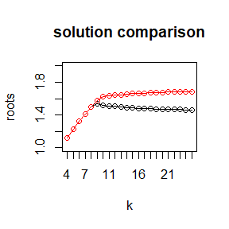

```r
plot(1:22,a1,main="solution comparison",xlab="k",ylab="roots",xaxt="n",type = "o",ylim=c(1,2))
lines(a2,type="o",col="red")
axis(1,at=1:22,labels = K)
```

### A-B-O blood type problem

Let the three alleles be A,B and O with allele frequencies p,q and r.The 6 genotype frequencies under HWE and complete counts are as follows.

```
##           [,1] [,2] [,3] [,4] [,5] [,6] [,7]
## genotype  AA   BB   OO   AO   BO   AB   Sum
## frequency p^2  q^2  r^2  2pr  2qr  2pq  1
## Count     nAA  nBB  nOO  nAO  nBO  nAB  n
```

Observed data: $n_{A.}=n_{AA}+n_{AO}=28$ (A-type), $n_{B.}=n_{BB}+n_{BO}=24$ (B-type), $n_{OO}=41$ (O-type), $n_{AB}=70$ (AB-type).

Use EM algorithm to solve MLE of p and q(consider missing data $n_{AA}$ and $n_{BB}$).

```r
#observed data loglikelihood
L<-function(nA,nB,nAB,nOO,p,q,r){
   nAB*log(2*p*q)+nA*log(p*2+2*p*r)+nB*log(q^2+2*q*r)+nOO*log(r^2)
}

em<-function(P,n.obs){
  n<-sum(n.obs)
  nA<-n.obs[1]
  nB<-n.obs[2]
  nOO<-n.obs[3]
  nAB<-n.obs[4]

  l<-rep(0,14)
  p<-q<-r<-rep(0,15)
  p[1]<-P[1]
  q[1]<-P[2]
  r[1]<-1-P[1]-P[2]
  for(i in 2:15){

    p.old<-p[i-1]
    q.old<-q[i-1]
    r.old<-r[i-1]

    nAA<-nA*p.old^2/(p.old^2+2*p.old*r.old)
    nBB<-nB*q.old^2/(q.old^2+2*q.old*r.old)
    nAO<-nA-nAA
    nBO<-nB-nBB

    p[i]<-(2*nAA+nAB+nAO)/(2*n)
    q[i]<-(2*nBB+nAB+nBO)/(2*n)
    r[i]<-(2*nOO+nAO+nBO)/(2*n)
    l[i-1]<-L(nA,nB,nAB,nOO,p[i],q[i],r[i])
  }
return(list(p=p,q=q,r=r,l=l))
}
n.obs=c(28,24,41,70)
P<-c(0.1,0.1)
a<-em(P,n.obs)
print(rbind(a$p,a$q,a$r))
```

```
##      [,1]      [,2]      [,3]     [,4]      [,5]      [,6]      [,7]      [,8]
## [1,]  0.1 0.3056658 0.3242869 0.326897 0.3272785 0.3273346 0.3273428 0.3273440
## [2,]  0.1 0.2926741 0.3080029 0.310075 0.3103751 0.3104191 0.3104256 0.3104265
## [3,]  0.8 0.4016601 0.3677101 0.363028 0.3623463 0.3622463 0.3622316 0.3622294
##           [,9]     [,10]     [,11]     [,12]     [,13]     [,14]     [,15]
## [1,] 0.3273442 0.3273442 0.3273442 0.3273442 0.3273442 0.3273442 0.3273442
## [2,] 0.3104267 0.3104267 0.3104267 0.3104267 0.3104267 0.3104267 0.3104267
## [3,] 0.3622291 0.3622291 0.3622291 0.3622291 0.3622291 0.3622291 0.3622291
```

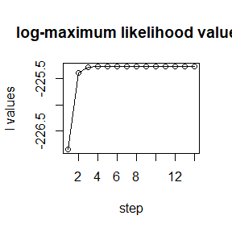

```r
plot(1:14,a$l,main="log-maximum likelihood values",type="o",xlab="step",ylab="l values")
```

# HW-2019-12-13

## Question

Exercise 3,4,5(pages 204,Advanced R) and Exercise 3,7(pages 214,Advanced R)

## Answer

### 1. Exercise 3(pages 204,Advanced R)

Use both for loops and lapply() to fit linear models to the $mtcars$ using the formulas stored in the list:

formulas <- list(mpg ~ disp,mpg ~ I(1 / disp),mpg ~ disp + wt,mpg ~ I(1 / disp) + wt)

```r
formulas <- list(mpg ~ disp,mpg ~ I(1 / disp),mpg ~ disp + wt,mpg ~ I(1 / disp) + wt)

#for loop
lm1<-vector("list",length(formulas))
for(i in seq_along(formulas)){
  lm1[[i]]<-lm(formulas[[i]],data = mtcars)
}
lm1
```

```
## [[1]]
##
## Call:
## lm(formula = formulas[[i]], data = mtcars)
##
## Coefficients:
## (Intercept)         disp
##    29.59985     -0.04122
##
##
## [[2]]
##
## Call:
## lm(formula = formulas[[i]], data = mtcars)
##
## Coefficients:
## (Intercept)    I(1/disp)
##       10.75      1557.67
##
##
## [[3]]
##
## Call:
## lm(formula = formulas[[i]], data = mtcars)
##
## Coefficients:
## (Intercept)         disp           wt
##    34.96055     -0.01772     -3.35083
##
##
## [[4]]
##
## Call:
## lm(formula = formulas[[i]], data = mtcars)
##
## Coefficients:
## (Intercept)    I(1/disp)           wt
##      19.024     1142.560       -1.798
```

```r
#lapply()
lm2<-lapply(seq_along(formulas),function(i) lm(formulas[[i]],data = mtcars))
lm2
```

```
## [[1]]
##
## Call:
## lm(formula = formulas[[i]], data = mtcars)
##
## Coefficients:
## (Intercept)         disp
##    29.59985     -0.04122
##
##
## [[2]]
##
## Call:
## lm(formula = formulas[[i]], data = mtcars)
##
## Coefficients:
## (Intercept)    I(1/disp)
##       10.75      1557.67
##
##
## [[3]]
##
## Call:
## lm(formula = formulas[[i]], data = mtcars)
##
## Coefficients:
## (Intercept)         disp           wt
##    34.96055     -0.01772     -3.35083
##
##
## [[4]]
##
## Call:
## lm(formula = formulas[[i]], data = mtcars)
##
## Coefficients:
## (Intercept)    I(1/disp)           wt
##      19.024     1142.560       -1.798
```

### 2. Exercise 4(pages 204,Advanced R)

Fit the model $mpg \sim disp$ to each of the bootstrap replicates of $mtcars$ in the list below by using a for loop and $lapply()$. Can you do it without an anonymous function?

```r
bootstraps<-lapply(1:10, function(i){
   rows <- sample(1:nrow(mtcars), rep = TRUE)
   mtcars[rows, ]
})

#for loop
l1<-vector("list",length(bootstraps))
for(i in seq_along(bootstraps)){
  l1[[i]]<-lm(mpg~disp,data = bootstraps[[i]])
}
l1
```

```
## [[1]]
##
## Call:
## lm(formula = mpg ~ disp, data = bootstraps[[i]])
##
## Coefficients:
## (Intercept)         disp
##     30.5373      -0.0444
##
##
## [[2]]
##
## Call:
## lm(formula = mpg ~ disp, data = bootstraps[[i]])
##
## Coefficients:
## (Intercept)         disp
##    29.22675     -0.04133
##
##
## [[3]]
##
## Call:
## lm(formula = mpg ~ disp, data = bootstraps[[i]])
##
## Coefficients:
## (Intercept)         disp
##    27.82696     -0.03348
##
##
## [[4]]
##
## Call:
## lm(formula = mpg ~ disp, data = bootstraps[[i]])
##
## Coefficients:
## (Intercept)         disp
##    32.01974     -0.05052
##
##
```

[output cut: 43 more lines]

```
## lm(formula = mpg ~ disp, data = bootstraps[[i]])
##
## Coefficients:
## (Intercept)         disp
##    30.46265     -0.04743
##
##
## [[10]]
##
## Call:
## lm(formula = mpg ~ disp, data = bootstraps[[i]])
##
## Coefficients:
## (Intercept)         disp
##    28.04377     -0.03652
```

```r
#lapply()
#do it without an anonymous function
l2<-lapply(bootstraps,lm,formula=mpg~disp)
l2
```

```
## [[1]]
##
## Call:
## FUN(formula = ..1, data = X[[i]])
##
## Coefficients:
## (Intercept)         disp
##     30.5373      -0.0444
##
##
## [[2]]
##
## Call:
## FUN(formula = ..1, data = X[[i]])
##
## Coefficients:
## (Intercept)         disp
##    29.22675     -0.04133
##
##
## [[3]]
##
## Call:
## FUN(formula = ..1, data = X[[i]])
##
## Coefficients:
## (Intercept)         disp
##    27.82696     -0.03348
##
##
## [[4]]
##
## Call:
## FUN(formula = ..1, data = X[[i]])
##
## Coefficients:
## (Intercept)         disp
##    32.01974     -0.05052
##
##
```

[output cut: 43 more lines]

```
## FUN(formula = ..1, data = X[[i]])
##
## Coefficients:
## (Intercept)         disp
##    30.46265     -0.04743
##
##
## [[10]]
##
## Call:
## FUN(formula = ..1, data = X[[i]])
##
## Coefficients:
## (Intercept)         disp
##    28.04377     -0.03652
```

### 3. Exercise 5(pages 204,Advanced R)

For each model in the previous two exercises, extract R2 using the function below.

```r
rsq <- function(mod) summary(mod)$r.squared

#model in exercise 3
unlist(lapply(lm1, rsq))
```

```
## [1] 0.7183433 0.8596865 0.7809306 0.8838038
```

```r
unlist(lapply(lm2, rsq))
```

```
## [1] 0.7183433 0.8596865 0.7809306 0.8838038
```

```r
#model in exercise 4
unlist(lapply(l1, rsq))
```

```
##  [1] 0.7817567 0.7813869 0.7191574 0.7880896 0.6350857 0.8092306 0.7153903
##  [8] 0.7117518 0.6652465 0.5906548
```

```r
unlist(lapply(l2, rsq))
```

```
##  [1] 0.7817567 0.7813869 0.7191574 0.7880896 0.6350857 0.8092306 0.7153903
##  [8] 0.7117518 0.6652465 0.5906548
```

### 4. Exercise 3(pages 214,Advanced R)

The following code simulates the performance of a t-test for non-normal data. Use sapply() and an anonymous function to extract the p-value from every trial.

Extra challenge: get rid of the anonymous function by using [[ directly.

```r
trials <- replicate(100,t.test(rpois(10,10),rpois(7,10)),simplify = FALSE)
#extract the p-value from every trial
sapply(trials,function(x) x$p.value)
```

```
##   [1] 0.25399172 0.95218057 0.96707126 0.73271297 0.23954469 0.44304177
##   [7] 0.82505300 0.47834643 0.83398501 0.28677782 0.32393591 0.58791171
##  [13] 0.37458782 0.03154822 0.27660703 0.81121328 0.07632266 0.74697953
##  [19] 0.89136198 0.19807802 0.03540943 0.46477246 0.31975085 0.36182827
##  [25] 0.47581765 0.24912119 0.77474406 0.77993677 0.78478879 0.59772964
##  [31] 0.71182391 0.21963120 0.69764942 0.66074430 0.44745990 0.29311517
##  [37] 0.81813960 0.91968642 0.62447455 0.28125422 0.12250357 0.16645727
##  [43] 0.86882267 0.92936738 0.23221383 0.20957034 0.45833984 0.82747566
##  [49] 0.96756786 0.98661304 0.86258363 0.03316359 0.44381805 0.12746016
##  [55] 0.75113209 0.49926890 0.32179203 0.06133945 0.88494487 0.66133103
##  [61] 0.08801281 0.20429664 0.31167672 0.04419619 0.48452025 0.81078022
##  [67] 0.36775963 0.74381327 0.15836056 0.05247675 0.81546092 0.95110556
##  [73] 0.50694686 0.82575616 0.84425564 0.22694392 0.58506727 0.05643706
##  [79] 0.05498503 0.74416657 0.86663861 0.16153192 0.98258238 0.28634770
##  [85] 0.38472659 0.18999235 0.53462651 0.58950555 0.32413849 0.57679670
##  [91] 0.60003972 0.38698635 0.50620011 0.58789266 0.26624001 0.14471008
##  [97] 0.66409688 0.04803668 0.75139328 0.77114599
```

```r
#Extra challenge: get rid of the anonymous function by using [[ directly.
sapply(trials,'[[',3)
```

```
##   [1] 0.25399172 0.95218057 0.96707126 0.73271297 0.23954469 0.44304177
##   [7] 0.82505300 0.47834643 0.83398501 0.28677782 0.32393591 0.58791171
##  [13] 0.37458782 0.03154822 0.27660703 0.81121328 0.07632266 0.74697953
##  [19] 0.89136198 0.19807802 0.03540943 0.46477246 0.31975085 0.36182827
##  [25] 0.47581765 0.24912119 0.77474406 0.77993677 0.78478879 0.59772964
##  [31] 0.71182391 0.21963120 0.69764942 0.66074430 0.44745990 0.29311517
##  [37] 0.81813960 0.91968642 0.62447455 0.28125422 0.12250357 0.16645727
##  [43] 0.86882267 0.92936738 0.23221383 0.20957034 0.45833984 0.82747566
##  [49] 0.96756786 0.98661304 0.86258363 0.03316359 0.44381805 0.12746016
##  [55] 0.75113209 0.49926890 0.32179203 0.06133945 0.88494487 0.66133103
##  [61] 0.08801281 0.20429664 0.31167672 0.04419619 0.48452025 0.81078022
##  [67] 0.36775963 0.74381327 0.15836056 0.05247675 0.81546092 0.95110556
##  [73] 0.50694686 0.82575616 0.84425564 0.22694392 0.58506727 0.05643706
##  [79] 0.05498503 0.74416657 0.86663861 0.16153192 0.98258238 0.28634770
##  [85] 0.38472659 0.18999235 0.53462651 0.58950555 0.32413849 0.57679670
##  [91] 0.60003972 0.38698635 0.50620011 0.58789266 0.26624001 0.14471008
##  [97] 0.66409688 0.04803668 0.75139328 0.77114599
```

### 5. Exercise 7(pages 214,Advanced R)

Implement mcsapply(), a multicore version of sapply(). Can you implement mcvapply(), a parallel version of vapply()? Why or why not?

```r
#Implement mcsapply()
library(parallel)
num_cores = detectCores()
cluster = makePSOCKcluster(num_cores)
mcsapply = function(cluster,X,FUN,...){
 res = parLapply(cluster,X,FUN,...)
 simplify2array(res)
}
stopCluster(cluster)
```

I can’t implement mcvapply(),a parallel version of vapply(),because the vapply function didn’t use lapply(),I can’t implement a parallel version of vapply() in R.

# HW-2019-12-20

## Question

You have already written an R function for Exercise 9.4 (page 277, Statistical Computing with R). Rewrite an Rcpp function for the same task.

Compare the generated random numbers by the two functions using $qqplot$.

Compare the computation time of the two functions with $microbenchmark$.

Comments your results.

## Answer

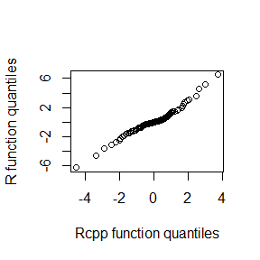

```r
## R function for Exercise 9.4
rw.Metropolis<-function(sigma,x0,N){
   x<-numeric(N)
   x[1]<-x0
   u<-runif(N)
   for(i in 2:N){
      y<-rnorm(1,x[i-1],sigma)
      if(u[i]<=(exp(abs(x[i-1]))/exp(abs(y)))) x[i]<-y
      else{
         x[i]<-x[i-1]
      }
   }
   return(x)
}

## Rcpp function for Exercise 9.4
library(Rcpp)
cppFunction('NumericVector rwC(double sigma, int x0, int N) {
      NumericVector out(N);
      out[0] = x0;

      for(int i=1;i<N;i++){
        double u = (double)rand() / RAND_MAX;

        double V1, V2, S;
        int phase = 0;
        double X;

        if ( phase == 0 ) {
         do {
            double U1 = (double)rand() / RAND_MAX;
            double U2 = (double)rand() / RAND_MAX;

            V1 = 2 * U1 - 1;
            V2 = 2 * U2 - 1;
            S = V1 * V1 + V2 * V2;
         } while(S >= 1 || S == 0);

         X = V1 * sqrt(-2 * log(S) / S);
         } else
         X = V2 * sqrt(-2 * log(S) / S);

        phase = 1 - phase;

        double y = sigma*X+out[i-1];

        if(u <= (exp(abs(out[i-1]))/exp(abs(y))))
           out[i] = y;
        else
           out[i] = out[i-1];
      }
      return out;
    }')

## initial values
N<-2000
sigma<-2
x0<-20

set.seed(123)
y1<-rwC(sigma,x0,N)
y2<-rw.Metropolis(sigma,x0,N)

## Compare the generated random numbers by the two functions using qqplot.
a<-ppoints(100)
Q1<-quantile(y1[500:2000],a)
Q2<-quantile(y2[500:2000],a)
qqplot(Q1,Q2,xlab="Rcpp function quantiles",ylab="R function quantiles")
```

```r
## Compare the computation time of the two functions with microbenchmark.
library(microbenchmark)
ts <- microbenchmark(rwR=rw.Metropolis(sigma,x0,N),rwRcpp=rwC(sigma,x0,N))
summary(ts)[,c(1,3,5,6)]
```

```
##     expr      lq median      uq
## 1    rwR 3470.90 3492.5 3569.30
## 2 rwRcpp  291.95  295.8  298.85
```

From the results, we can find that the Rcpp function greatly decreases the computation time.